# R语言实现随机森林(2)Construct model

jmzeng@163.com

6/12/2017

> - [我的博客](http://www.bio-info-trainee.com/)
> - [我们的论坛](http://www.biotrainee.com/forum.php)
> - [捐赠我](http://www.bio-info-trainee.com/donate)

> 随机森林算法只需要两个输入文件：
- 多个变量在多个样本的数据矩阵
- 每个样本的结果

建立好了模型，就可以根据新的样本的多个变量的值来预测该样本的结果了。

## 安装并加载必须的packages

> 如果你还没有安装，就运行下面的代码安装：

```r
install.packages("randomForest")
install.packages("ROCR")
install.packages("Hmisc")
source("http://bioconductor.org/biocLite.R")
biocLite("genefilter")
```

> 如果你安装好了，就直接加载它们即可

```r
library(randomForest)
library(ROCR)
library(genefilter)
library(Hmisc)
```

## 制作模型的输入矩阵

```r
load('ML_RF_input.Rdata')
dim(training_data)
```

```
## [1] 12437   286
```

```r
training_data[1:4,1:4]
```

```
##       GSM36777 GSM36778 GSM36779 GSM36780
## TPT1  15.32042 15.97258 15.92571 15.84866
## HUWE1 15.29929 15.98843 15.84894 16.05216
## RPS10 15.28570 16.06372 15.52021 15.47341
## RPL41 15.20232 15.94103 15.84793 15.83168
```

```r
ffun=filterfun(pOverA(p = 0.2, A = 100), cv(a = 0.7, b = 10))
filt=genefilter(2^training_data,ffun)
filt_Data=training_data[filt,]

dim(filt_Data)
```

```
## [1] 1960  286
```

```r
filt_Data[1:4,1:4]
```

```
##          GSM36777 GSM36778 GSM36779 GSM36780
## IGLC1    13.56318 12.32474 13.89471 16.19136
## SLC39A6  14.23702 14.85154 14.60434 12.59994
## SERPINA3 14.75499 11.94570 13.75731 11.81614
## S100A6   12.91608 12.28789 12.50747 12.74865
```

```r
predictor_data=t(filt_Data)
str(predictor_data)
```

```
##  num [1:286, 1:1960] 13.6 12.3 13.9 16.2 15.8 ...
##  - attr(*, "dimnames")=List of 2
##   ..$ : chr [1:286] "GSM36777" "GSM36778" "GSM36779" "GSM36780" ...
##   ..$ : chr [1:1960] "IGLC1" "SLC39A6" "SERPINA3" "S100A6" ...
```

> 如上所示，如果某个探针在样本群体表达差异不大，那么这样的基因对于样本分类的效果微乎其微，是需要过滤掉的。

这里我们借用genefilter包的filterfun函数来行使过滤功能，过滤的标准有两个，如下所示:

- 1. At least 20% of samples should have raw intensity greater than 100;
- 2. The coefficient of variation (sd/mean) is between 0.7 and 10.

当然，这个表达矩阵还需要转置，因为RandomForests包默认输入矩阵的列代表着predictor variables (genes)

## 然后制作样本的结果文件

> 随机森林模型就是根据一大堆的特征来对样本进行判别，所以训练的时候，首先样本要有特征值，在我们这个例子里面，就是每个样本的每个基因的表达量，但是还需要知道样本的本身的情况，在这里用是否癌症复发与否作为样本的状态值，供随机森林模型训练。

```r
head(training_clinical)
```

```
##                      title geo_accession            characteristics_ch1
## GSM36777   Wang4812_JA_277      GSM36777 bone relapses (1=yes, 0=no): 0
## GSM36778   Wang4813_JA_278      GSM36778 bone relapses (1=yes, 0=no): 0
## GSM36779  Wang4630_JA798@C      GSM36779 bone relapses (1=yes, 0=no): 0
## GSM36780 Wang4889_JA_846@2      GSM36780 bone relapses (1=yes, 0=no): 0
## GSM36781 Wang4857_JA_765@2      GSM36781 bone relapses (1=yes, 0=no): 0
## GSM36782    Wang4585_JA600      GSM36782 bone relapses (1=yes, 0=no): 0
```

```r
table(as.character(training_clinical$characteristics_ch1))
```

```
##
## bone relapses (1=yes, 0=no): 0 bone relapses (1=yes, 0=no): 1
##                            217                             69
```

```r
## 根据信息匹配该癌症样本是否复发
target=as.numeric(sapply(as.character(training_clinical$characteristics_ch1),function(x) strsplit(x,':')[[1]][2]))

target[target==0]="NoRelapse"
target[target==1]="Relapse"
target=as.factor(target)
head(target)
```

```
## [1] NoRelapse NoRelapse NoRelapse NoRelapse NoRelapse NoRelapse
## Levels: NoRelapse Relapse
```

## 最后运行建模

先设置建模的一些参数

```r
tmp = as.vector(table(target))
num_classes = length(tmp)
min_size = tmp[order(tmp,decreasing=FALSE)[1]]
sampsizes = rep(min_size,num_classes)
```

然后直接运行randomForest包里面的randomForest函数即可，非常简单

```r
rf_output=randomForest(x=predictor_data, y=target, importance = TRUE, ntree = 10001, proximity=TRUE, sampsize=sampsizes)
save(rf_output,file='rf_output.Rdata')
```

上面得到的**rf_output**就是我们根据训练数据构建好的随机森林模型啦。

> **rf_output** 是一个非常复杂的对象，里面含有18个元素，下面的模型诊断会用到其中一些。

# 模型诊断

> 可以计算 sensitivity, specificity, accuracy 等等

```r
load('rf_output.Rdata')
rf_importances=importance(rf_output, scale=FALSE)
head(rf_importances)
```

```
##             NoRelapse       Relapse MeanDecreaseAccuracy MeanDecreaseGini
## IGLC1    8.452490e-05  3.655836e-04         1.244495e-04       0.13896539
## SLC39A6  2.195730e-05  5.039129e-05         2.618922e-05       0.02239129
## SERPINA3 1.286141e-05 -3.076749e-05         7.056685e-06       0.02186602
## S100A6   5.464032e-06 -2.424916e-05         1.291330e-06       0.02890773
## PIP      1.851206e-05  1.541625e-04         3.718111e-05       0.05858246
## IGFBP5   1.443045e-05  7.787220e-05         2.263168e-05       0.04808511
```

```r
confusion=rf_output$confusion
confusion
```

```
##           NoRelapse Relapse class.error
## NoRelapse       183      34   0.1566820
## Relapse          42      27   0.6086957
```

```r
sensitivity=(confusion[2,2]/(confusion[2,2]+confusion[2,1]))*100
sensitivity
```

```
## [1] 39.13043
```

```r
specificity=(confusion[1,1]/(confusion[1,1]+confusion[1,2]))*100
specificity
```

```
## [1] 84.3318
```

```r
overall_error=rf_output$err.rate[length(rf_output$err.rate[,1]),1]*100
overall_error
```

```
##      OOB
## 26.57343
```

```r
class1_error=paste(rownames(confusion)[1]," error rate= ",confusion[1,3], sep="")
class1_error
```

```
## [1] "NoRelapse error rate= 0.15668202764977"
```

```r
class2_error=paste(rownames(confusion)[2]," error rate= ",confusion[2,3], sep="")
class2_error
```

```
## [1] "Relapse error rate= 0.608695652173913"
```

```r
overall_accuracy=100-overall_error
overall_accuracy
```

```
##      OOB
## 73.42657
```

### 显示最重要的30个基因

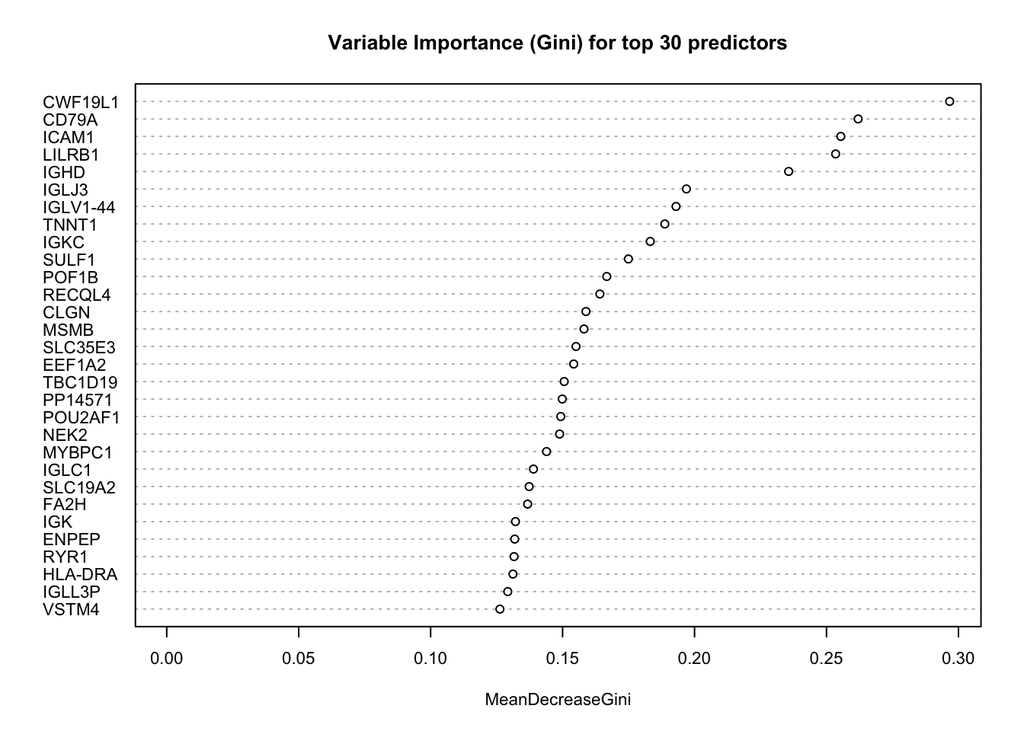

```r
varImpPlot(rf_output, type=2, n.var=30, scale=FALSE, main="Variable Importance (Gini) for top 30 predictors",cex =.7)
```

## 显示模型在训练数据的分类效果

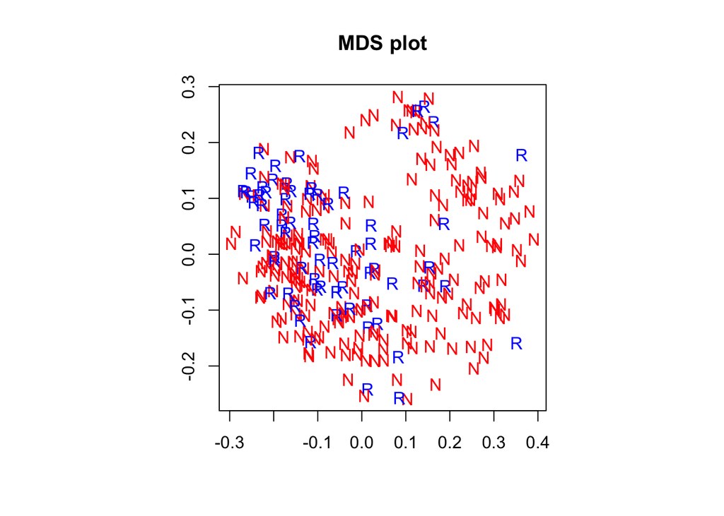

```r
target_labels=as.vector(target)
target_labels[target_labels=="NoRelapse"]="N"
target_labels[target_labels=="Relapse"]="R"
MDSplot(rf_output, target, k=2, xlab="", ylab="", pch=target_labels, palette=c("red", "blue"), main="MDS plot")
```

## create an ROC curve and calculate the area under it (AUC)

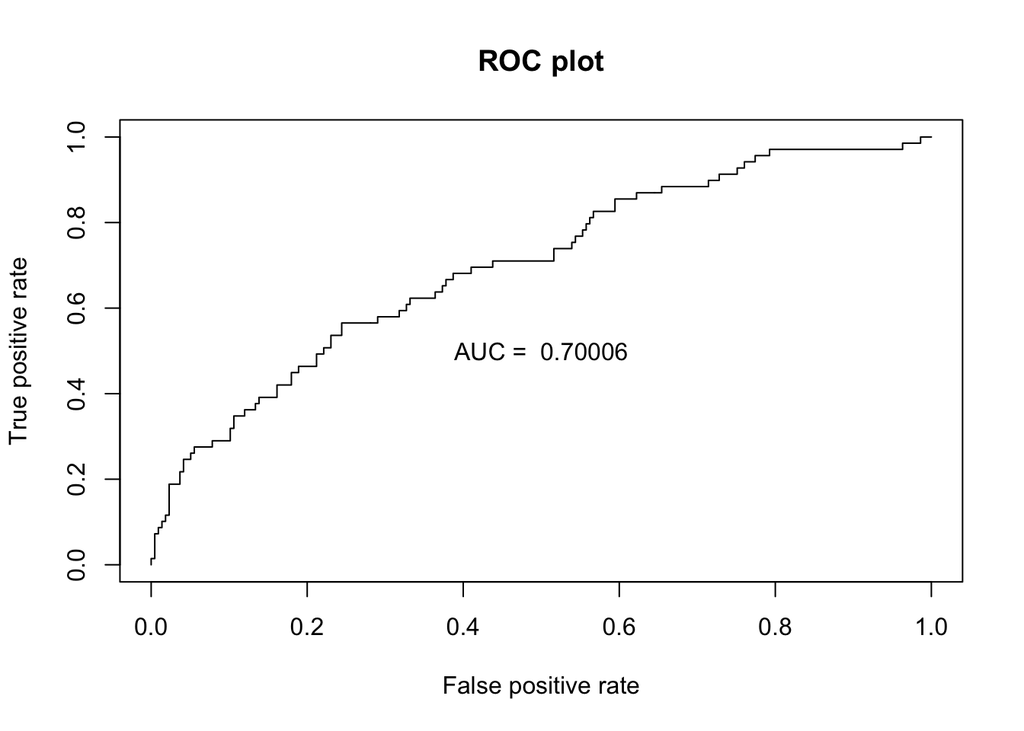

```r
predictions=as.vector(rf_output$votes[,2])
pred=prediction(predictions,target)
#First calculate the AUC value
perf_AUC=performance(pred,"auc")
AUC=perf_AUC@y.values[[1]]
#Then, plot the actual ROC curve
perf_ROC=performance(pred,"tpr","fpr")
plot(perf_ROC, main="ROC plot")
text(0.5,0.5,paste("AUC = ",format(AUC, digits=5, scientific=FALSE)))
```

## back-to-back histogram of vote distributions for Relapse and NoRelapse

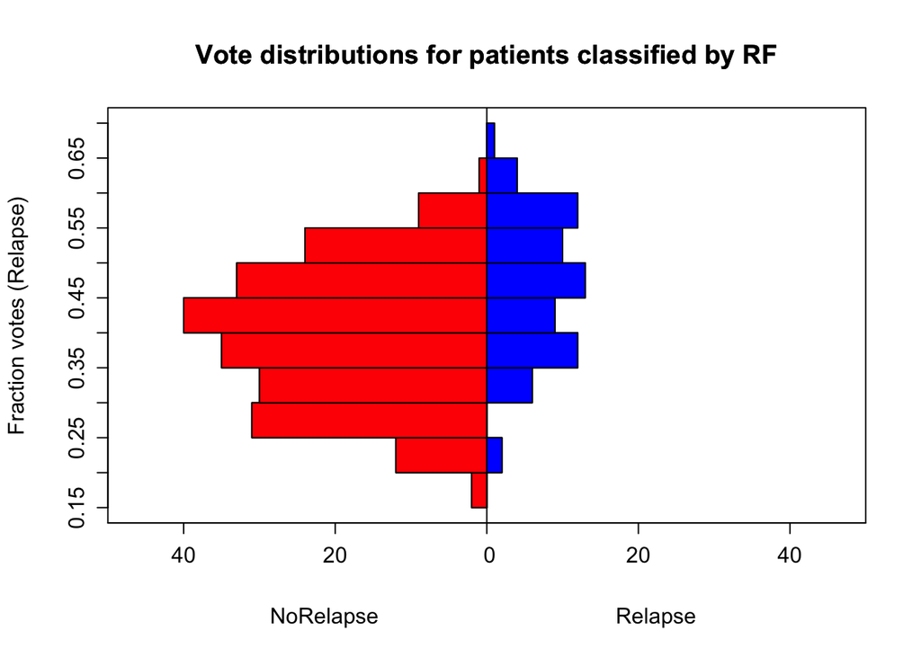

```r
options(digits=2)
out <- histbackback(split(rf_output$votes[,"Relapse"], target), probability=FALSE, xlim=c(-50,50), main = 'Vote distributions for patients classified by RF', axes=TRUE, ylab="Fraction votes (Relapse)")
barplot(-out$left, col="red" , horiz=TRUE, space=0, add=TRUE, axes=FALSE)
barplot(out$right, col="blue", horiz=TRUE, space=0, add=TRUE, axes=FALSE)
```

## 最后我们看看训练集本身对这个随机森林模型的适应情况

```r
case_predictions=cbind(training_clinical,target,rf_output$predicted,rf_output$votes)
head(case_predictions)
```

```
##                      title geo_accession            characteristics_ch1
## GSM36777   Wang4812_JA_277      GSM36777 bone relapses (1=yes, 0=no): 0
## GSM36778   Wang4813_JA_278      GSM36778 bone relapses (1=yes, 0=no): 0
## GSM36779  Wang4630_JA798@C      GSM36779 bone relapses (1=yes, 0=no): 0
## GSM36780 Wang4889_JA_846@2      GSM36780 bone relapses (1=yes, 0=no): 0
## GSM36781 Wang4857_JA_765@2      GSM36781 bone relapses (1=yes, 0=no): 0
## GSM36782    Wang4585_JA600      GSM36782 bone relapses (1=yes, 0=no): 0
##             target rf_output$predicted NoRelapse Relapse
## GSM36777 NoRelapse             Relapse      0.50    0.50
## GSM36778 NoRelapse             Relapse      0.45    0.55
## GSM36779 NoRelapse           NoRelapse      0.59    0.41
## GSM36780 NoRelapse           NoRelapse      0.72    0.28
## GSM36781 NoRelapse           NoRelapse      0.76    0.24
## GSM36782 NoRelapse           NoRelapse      0.63    0.37
```

```r
table(case_predictions[,4:5])
```

```
##            rf_output$predicted
## target      NoRelapse Relapse
##   NoRelapse       183      34
##   Relapse          42      27
```